# Análisis Completo de la Serie Temporal del número de afiliados a la Seguridad Social

## 6.3 Clasificación serie2

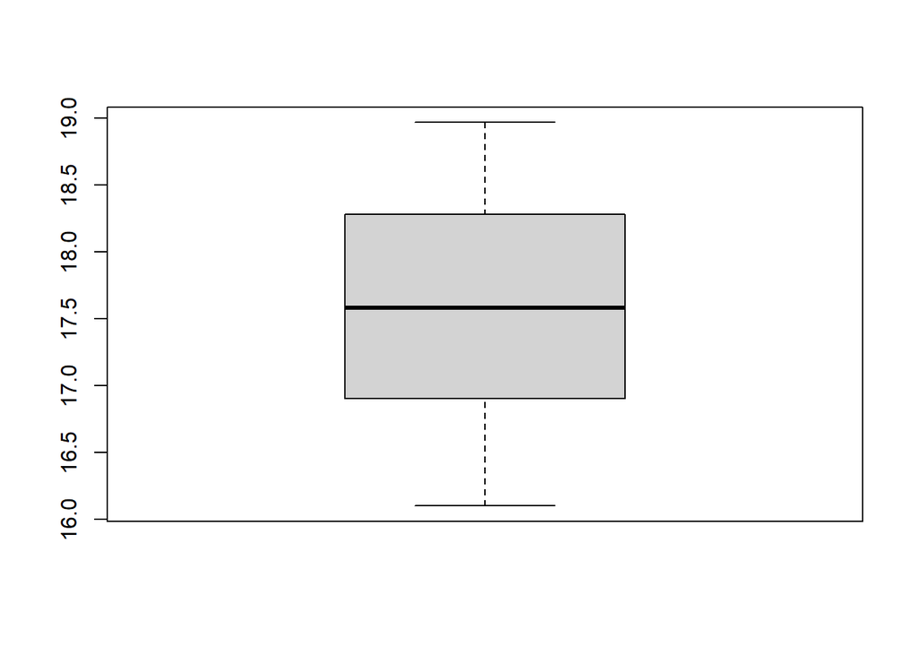

```r
boxplot(serie2)
```

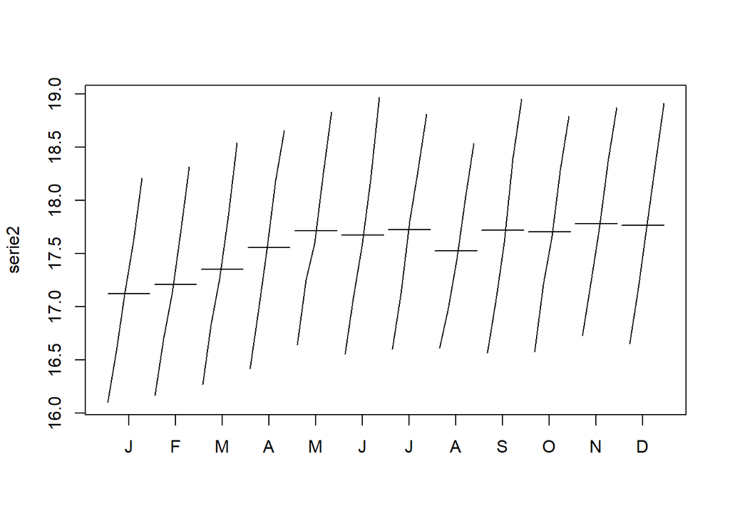

```r
monthplot(serie2)
```

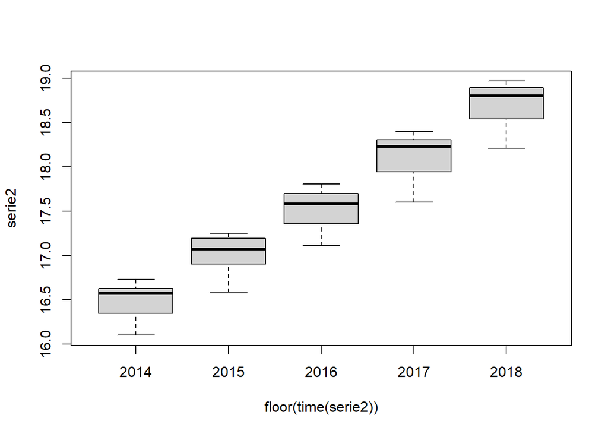

```r
boxplot(serie2~floor(time(serie2)))
```

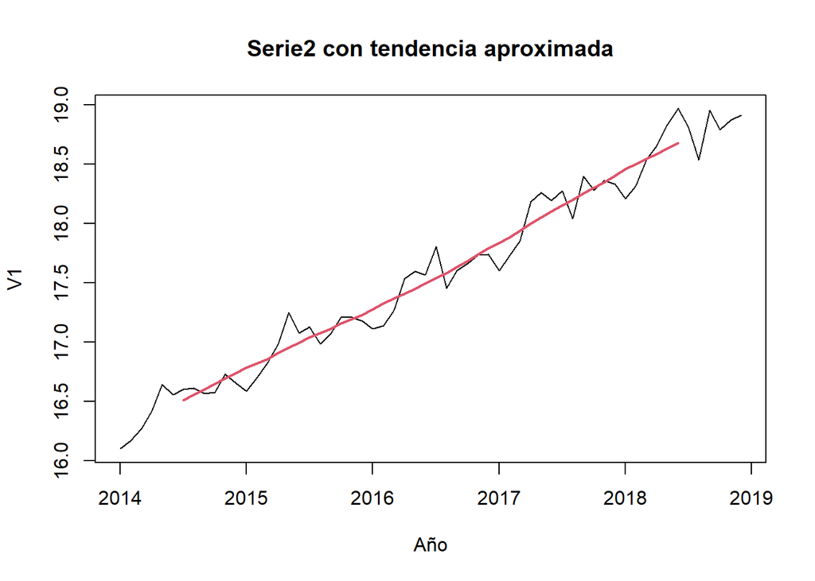

```r
k = 6 #(Orden 2*k=freq)
trend2 = filter(serie2, c(1/(4*k),rep(1/(2*k),2*k-1),1/(4*k)), sides = 2)
plot(serie2, main = "Serie2 con tendencia aproximada", xlab = "Año")
lines(trend2, col = 2, lwd = 2)
```

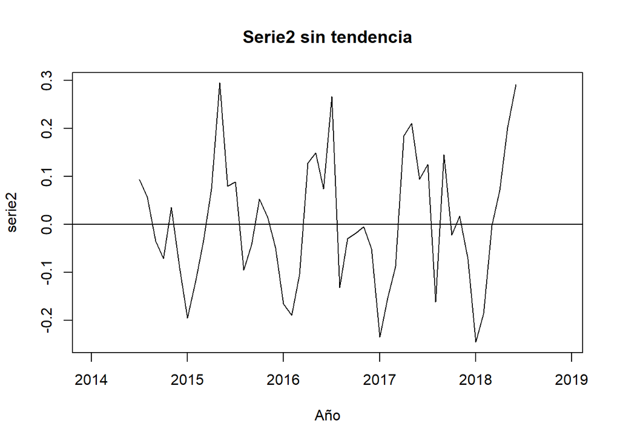

```r
plot(serie2-trend2, main = "Serie2 sin tendencia", xlab = "Año")
abline(h =  0)
```

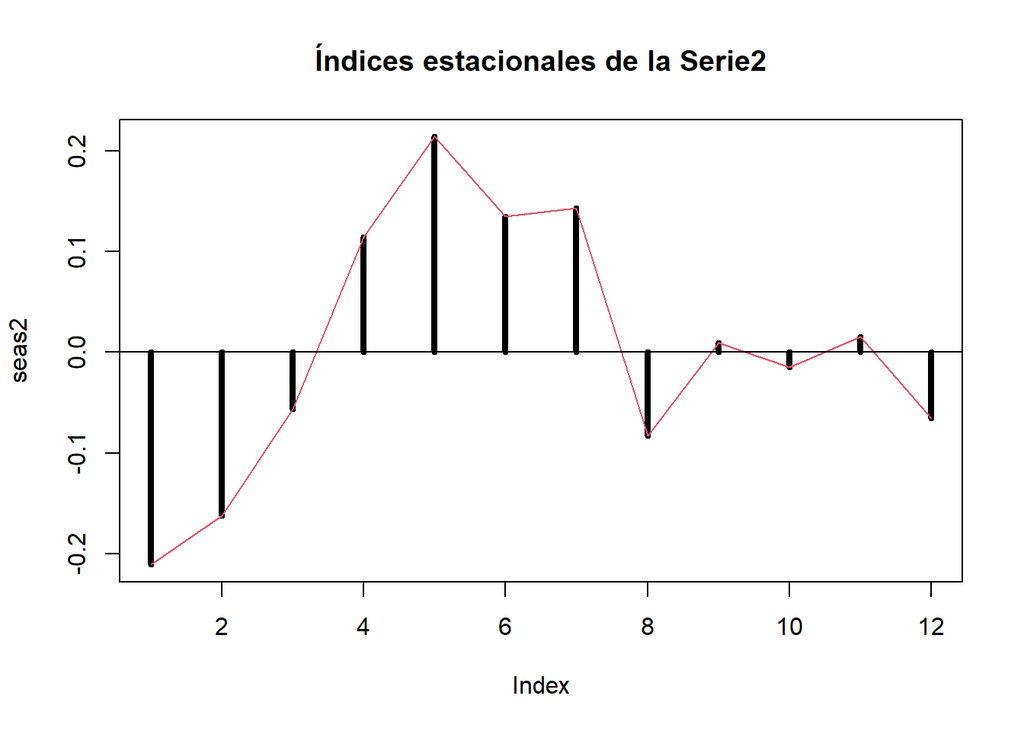

```r
seas2 = apply(matrix(serie2-trend2,nrow=2*k), 1, mean, na.rm=T)
plot(seas2, type = "h", lwd = 4, main  ="Índices estacionales de la Serie2")
lines(seas2, col = 2)
abline(h = 0)
```

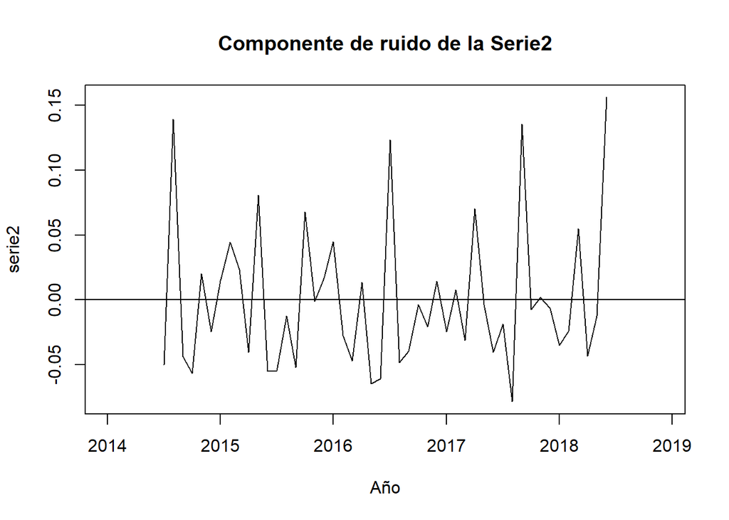

```r
plot(serie2-trend2-seas2, main = "Componente de ruido de la Serie2", xlab = "Año")
abline(h = 0)
```

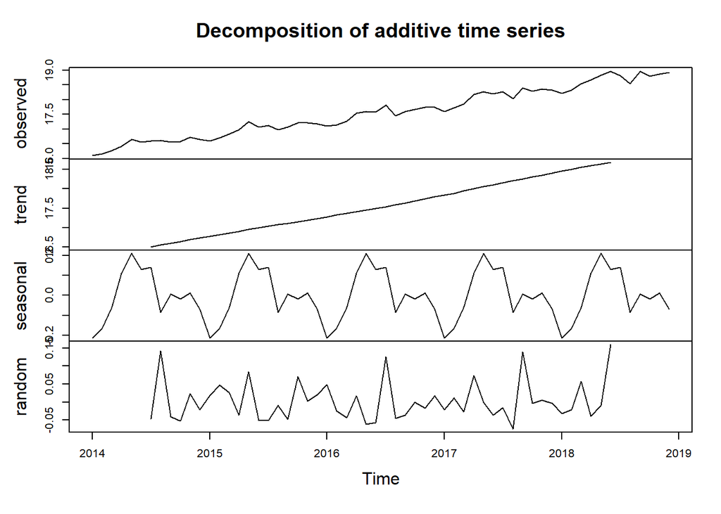

```r
plot(decompose(serie2))
```

**Observaciones:**  
Hay tendencia lineal creciente y estacionalidad aditiva por la homocedasticidad.  
Es una serie de tipo 4: AAA.

**Interpretación:**  
La recuperación positiva económica da lugar a un crecimiento constante del número de afiliados a la seguridad social en España.

## 6.4 Predicciones con la serie2

Volvemos a definir las funciones necesareas.

```r
mse4bis <- function(par){
  h <- HoltWinters(serie2, alpha = par[1], beta = par[2], gamma = par[3])
  mean((serie2-fitted(h)[,1])^2)
}
rmse4bis <- function(par){
  h <- HoltWinters(serie2, alpha = par[1], beta = par[2], gamma = par[3])
  sqrt(mean((serie2-fitted(h)[,1])^2))
}
mae4bis <- function(par){
  h <- HoltWinters(serie2, alpha = par[1], beta = par[2], gamma = par[3])
  mean(abs(serie2-fitted(h)[,1]))
}

mse6bis <- function(par){
  h <- HoltWinters(serie2, alpha = par[1], beta = par[2], gamma = par[3], seasonal = "multip")
  mean((serie2-fitted(h)[,1])^2)
}
rmse6bis <- function(par){
  h <- HoltWinters(serie2, alpha = par[1], beta = par[2], gamma = par[3], seasonal = "multip")
  sqrt(mean((serie2-fitted(h)[,1])^2))
}
mae6bis <- function(par){
  h <- HoltWinters(serie2, alpha = par[1], beta = par[2], gamma = par[3], seasonal = "multip")
  mean(abs(serie2-fitted(h)[,1]))
}
```

### 6.4.1 Suponiendo que es AAA (a mano)

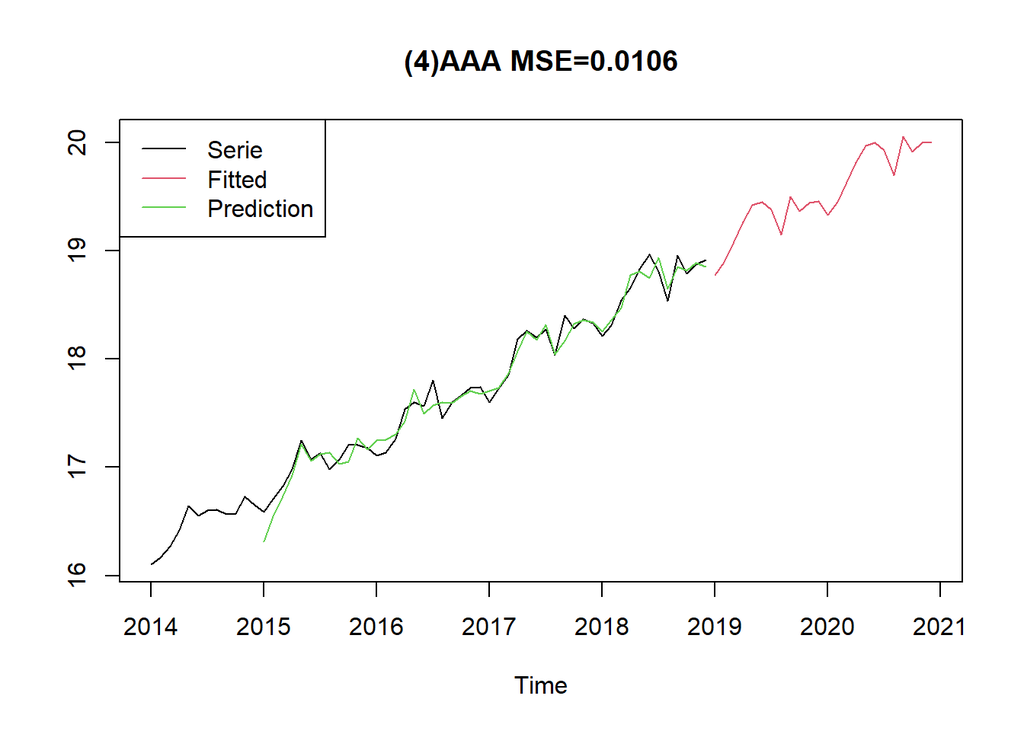

```r
par = c(0.5,0.5,0.5)
sol <- optim(par, mse4bis, method = "L-BFGS-B", lower = c(1e-4,1e-4,1e-4), upper = c(0.9999,0.9999,0.9999))
h41 <- HoltWinters(serie2, alpha = sol$par[1], beta = sol$par[2], gamma = sol$par[3])
ph41 <- predict(h41,24)
ts.plot(serie2, ph41, h41$fitted[,1], col = c(1,2,3), main = paste0("(4)AAA MSE=", round(sol$value,4)))
legend("topleft", legend = c("Serie", "Fitted", "Prediction"), col = c(1,2,3), lty = 1, bty = "y")
```

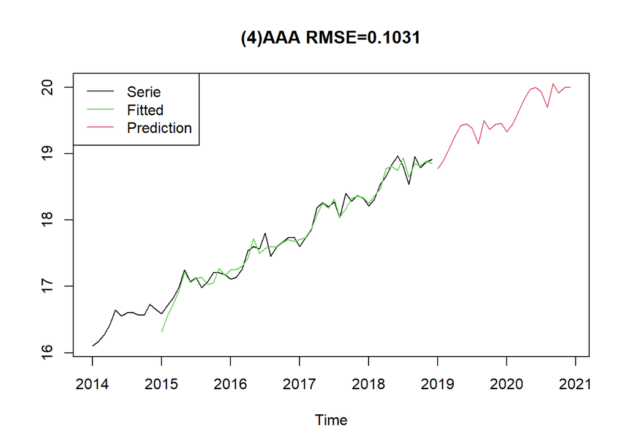

```r
sol <- optim(par, rmse4bis, method = "L-BFGS-B", lower = c(1e-4,1e-4,1e-4), upper = c(0.9999,0.9999,0.9999))
h42 <- HoltWinters(serie2, alpha = sol$par[1], beta = sol$par[2], gamma = sol$par[3])
ph42 <- predict(h42,24)
ts.plot(serie2, ph42, h42$fitted[,1], col = c(1,2,3), main = paste0("(4)AAA RMSE=", round(sol$value,4)))
legend("topleft", legend = c("Serie", "Fitted", "Prediction"), col = c(1,3,2), lty = 1, bty = "y")
```

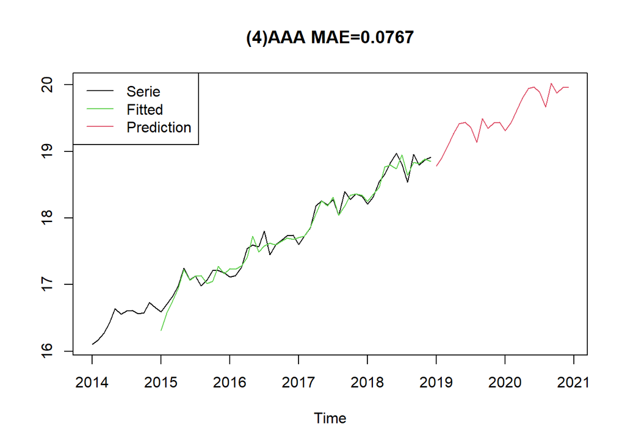

```r
sol <- optim(par, mae4bis, method = "L-BFGS-B", lower = c(1e-4,1e-4,1e-4), upper = c(0.9999,0.9999,0.9999))
h43 <- HoltWinters(serie2, alpha = sol$par[1], beta = sol$par[2], gamma = sol$par[3])
ph43 <- predict(h43,24)
ts.plot(serie2, ph43, h43$fitted[,1], col = c(1,2,3), main = paste0("(4)AAA MAE=", round(sol$value,4)))
legend("topleft", legend = c("Serie", "Fitted", "Prediction"), col = c(1,3,2), lty = 1, bty = "y")
```

### 6.4.2 Suponiendo que es AAM (a mano)

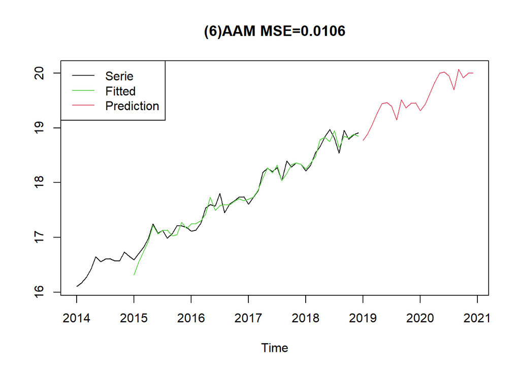

```r
par = c(0.5,0.5,0.5)
sol <- optim(par, mse6bis, method = "L-BFGS-B", lower = c(1e-4,1e-4,1e-4), upper = c(0.9999,0.9999,0.9999))
h61 <- HoltWinters(serie2, alpha = sol$par[1], beta = sol$par[2], gamma = sol$par[3], seasonal = "m")
ph61 <- predict(h61,24)
ts.plot(serie2, ph61, h61$fitted[,1], col = c(1,2,3), main=paste0("(6)AAM MSE=", round(sol$value,4)))
legend("topleft", legend = c("Serie", "Fitted", "Prediction"), col = c(1,3,2), lty = 1, bty = "y")
```

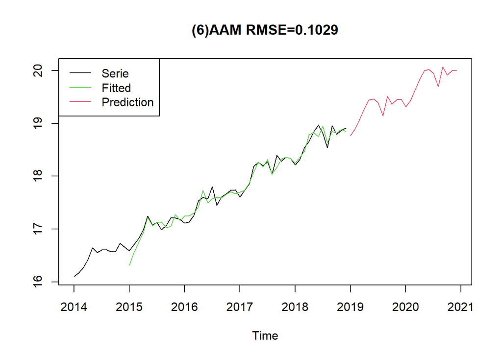

```r
sol <- optim(par, rmse6bis, method = "L-BFGS-B", lower = c(1e-4,1e-4,1e-4), upper = c(0.9999,0.9999,0.9999))
h62 <- HoltWinters(serie2, alpha = sol$par[1], beta = sol$par[2], gamma = sol$par[3], seasonal = "m")
ph62 <- predict(h62,24)
ts.plot(serie2, ph62, h62$fitted[,1], col = c(1,2,3), main = paste0("(6)AAM RMSE=", round(sol$value,4)))
legend("topleft", legend = c("Serie", "Fitted", "Prediction"), col = c(1,3,2), lty = 1, bty = "y")
```

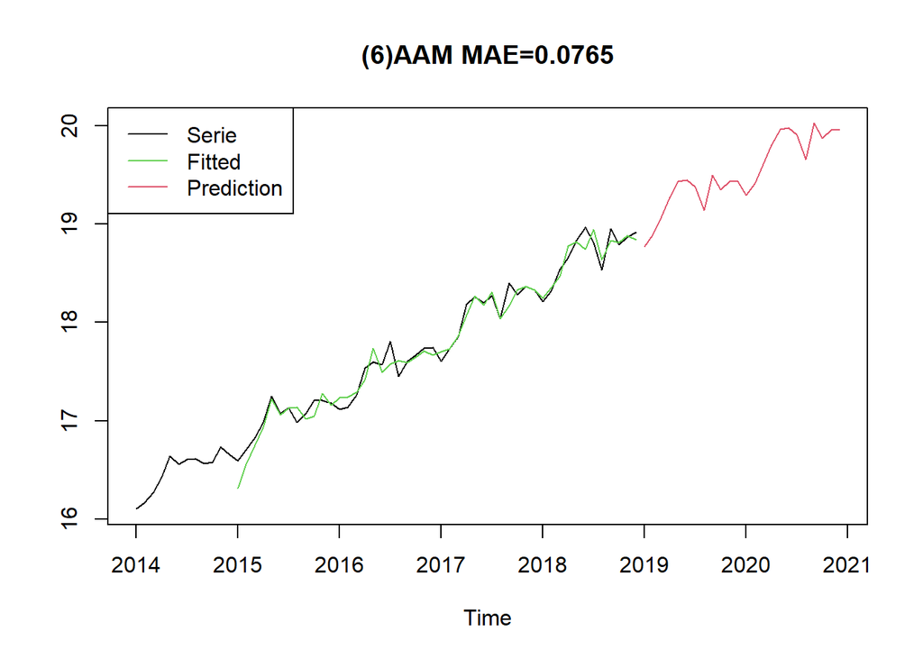

```r
sol <- optim(par, mae6bis, method = "L-BFGS-B", lower = c(1e-4,1e-4,1e-4), upper = c(0.9999,0.9999,0.9999))
h63 <- HoltWinters(serie2, alpha = sol$par[1], beta = sol$par[2], gamma = sol$par[3], seasonal = "m")
ph63 <- predict(h63,24)
ts.plot(serie2, ph63, h63$fitted[,1], col = c(1,2,3), main=paste0("(6)AAM MAE=", round(sol$value,4)))
legend("topleft", legend = c("Serie", "Fitted", "Prediction"), col = c(1,3,2), lty = 1, bty = "y")
```

### 6.4.3 Automáticamente

```r
(h4bis <- HoltWinters(serie2, alpha = NULL, beta = NULL, gamma = NULL, seasonal = "additive"))
```

```
## Holt-Winters exponential smoothing with trend and additive seasonal component.
##
## Call:
## HoltWinters(x = serie2, alpha = NULL, beta = NULL, gamma = NULL,     seasonal = "additive")
##
## Smoothing parameters:
##  alpha: 0.398768
##  beta : 0.006909952
##  gamma: 0.8318089
##
## Coefficients:
##             [,1]
## a   18.939477834
## b    0.045844671
## s1  -0.205941480
## s2  -0.131913706
## s3   0.010918522
## s4   0.147269229
## s5   0.254258534
## s6   0.236028780
## s7   0.119722119
## s8  -0.159095390
## s9   0.151661909
## s10 -0.033837776
## s11  0.004403121
## s12 -0.031193464
```

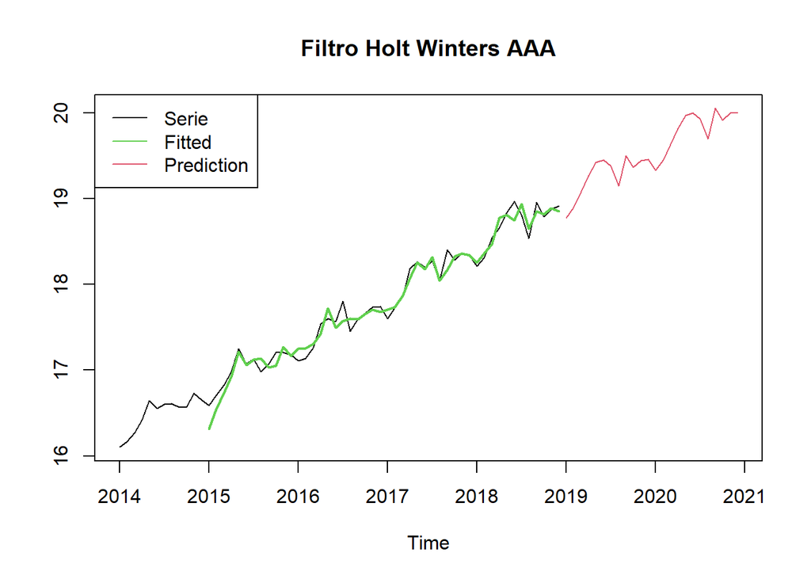

```r
pred4bis = predict(h4bis,24)
ts.plot(serie2, fitted(h4bis)[,1], pred4bis, col = c(1,3,2), lwd = c(1,2), main = "Filtro Holt Winters AAA")
legend("topleft", legend = c("Serie", "Fitted", "Prediction"), col = c(1,3,2), lty = 1, bty = "y")
```

```r
(h6bis <- HoltWinters(serie2, alpha = NULL, beta = NULL, gamma = NULL, seasonal = "multiplicative"))
```

```
## Holt-Winters exponential smoothing with trend and multiplicative seasonal component.
##
## Call:
## HoltWinters(x = serie2, alpha = NULL, beta = NULL, gamma = NULL,     seasonal = "multiplicative")
##
## Smoothing parameters:
##  alpha: 0.4076935
##  beta : 0.00671062
##  gamma: 0.8287031
##
## Coefficients:
##            [,1]
## a   18.94065357
## b    0.04580845
## s1   0.98853281
## s2   0.99253992
## s3   1.00031015
## s4   1.00802347
## s5   1.01406364
## s6   1.01293836
## s7   1.00694344
## s8   0.99179422
## s9   1.00827168
## s10  0.99831789
## s11  1.00032498
## s12  0.99825682
```

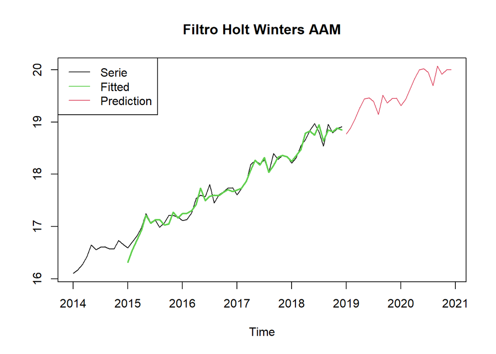

```r
pred6bis = predict(h6bis,24)
ts.plot(serie2, fitted(h6bis)[,1], pred6bis, col = c(1,3,2), lwd = c(1,2), main = "Filtro Holt Winters AAM")
legend("topleft", legend = c("Serie", "Fitted", "Prediction"), col = c(1,3,2), lty = 1, bty = "y")
```

```r
summary(pred4bis-pred6bis)
```

```
##     pred4bis
##  Min.   :-0.023628
##  1st Qu.:-0.013423
##  Median :-0.002229
##  Mean   :-0.003746
##  3rd Qu.: 0.003559
##  Max.   : 0.017379
```

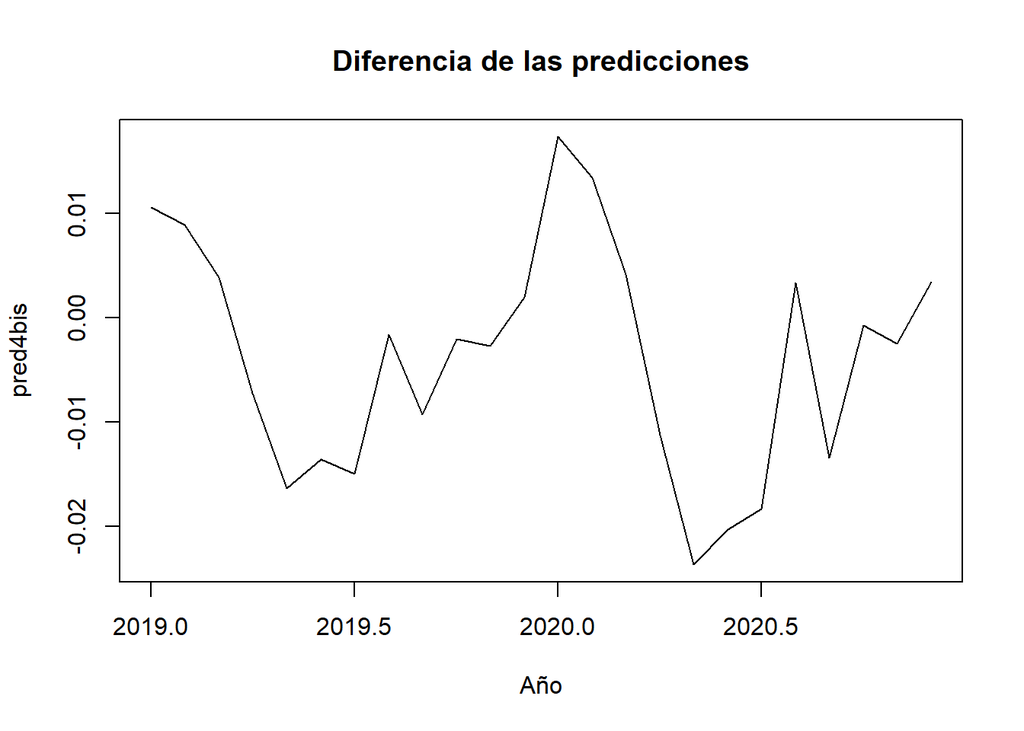

```r
plot(pred4bis-pred6bis, main = "Diferencia de las predicciones", xlab = "Año")
```

**Interpretación:**  
Observamos que ambos filtros son extremadamente parecidos pero dada la clara clasificación de la serie en cuestión escogemos el filtro Holt-Winters para series con estacionalidad aditiva.

```r
filtro_bis <- h4bis
prediction_bis <- pred4bis
```

# Parte 7: Comparación de predicciones

## 7.1 Serie entera y desde 2014

```r
summary(prediction-prediction_bis)
```

```
##    prediction
##  Min.   :-0.20059
##  1st Qu.:-0.14301
##  Median :-0.11262
##  Mean   :-0.11409
##  3rd Qu.:-0.07759
##  Max.   :-0.02187
```

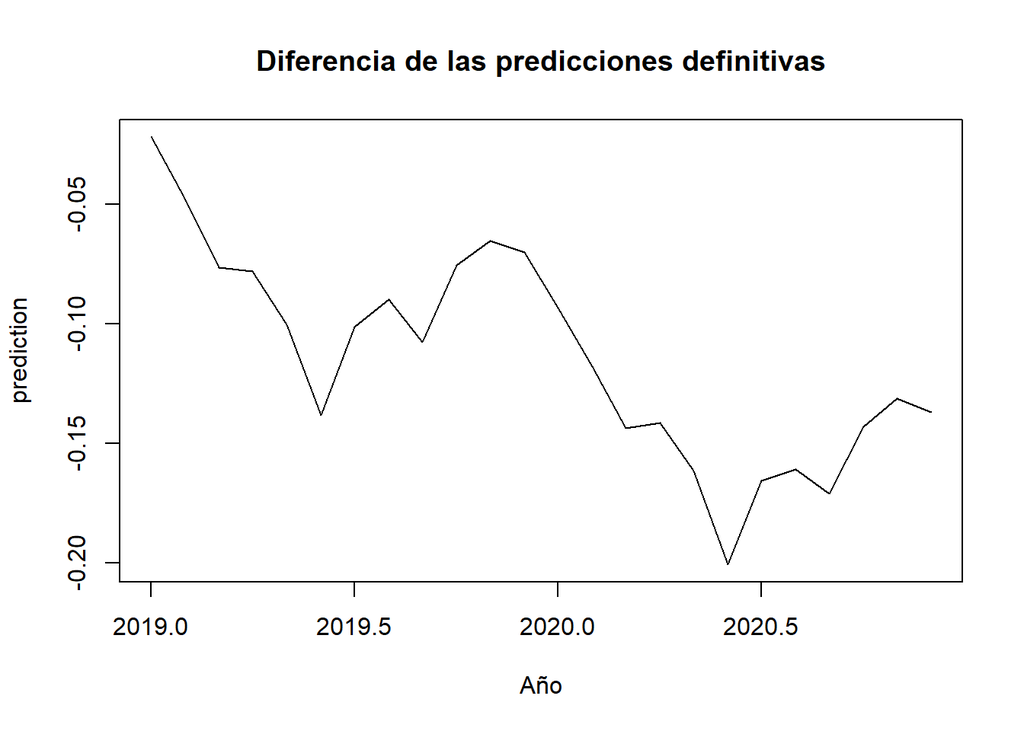

```r
plot(prediction-prediction_bis, main = "Diferencia de las predicciones definitivas", xlab = "Año")
```

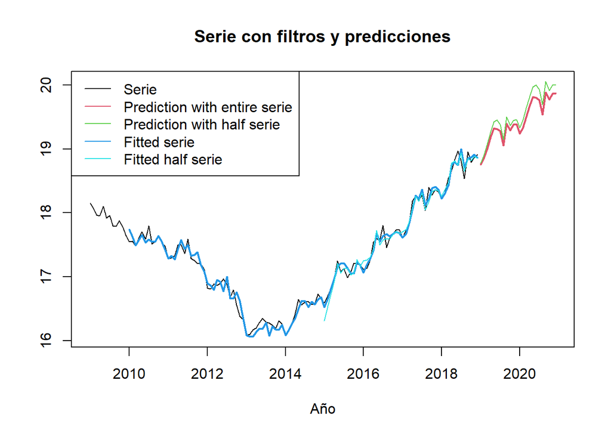

```r
ts.plot(serie, prediction, prediction_bis, fitted(filtro)[,1],fitted(filtro_bis)[,1], col = c(1,2,3,4,5), lwd=c(1,2), main = "Serie con filtros y predicciones", xlab = "Año")
legend("topleft", legend = c("Serie", "Prediction with entire serie", "Prediction with half serie", "Fitted serie", "Fitted half serie"), col = c(1,2,3,4,5), lty = 1, bty = "y")
```

## 7.2 Comparación predicciones con los dos siguientes años reales

Definimos una función del Mean Squared Error entre dos series.

```r
error <- function(serie1,serie2){
  mean((serie1-serie2)^2)
}
```

### 7.2.1 Primer año (2019)

```r
futuro <- window(data, start = 2019, end = c(2019,12))
summary(futuro-prediction)
```

```
##      futuro
##  Min.   :-1.725e-01
##  1st Qu.:-4.691e-02
##  Median : 6.735e-05
##  Mean   : 2.542e-03
##  3rd Qu.: 4.572e-02
##  Max.   : 1.974e-01
```

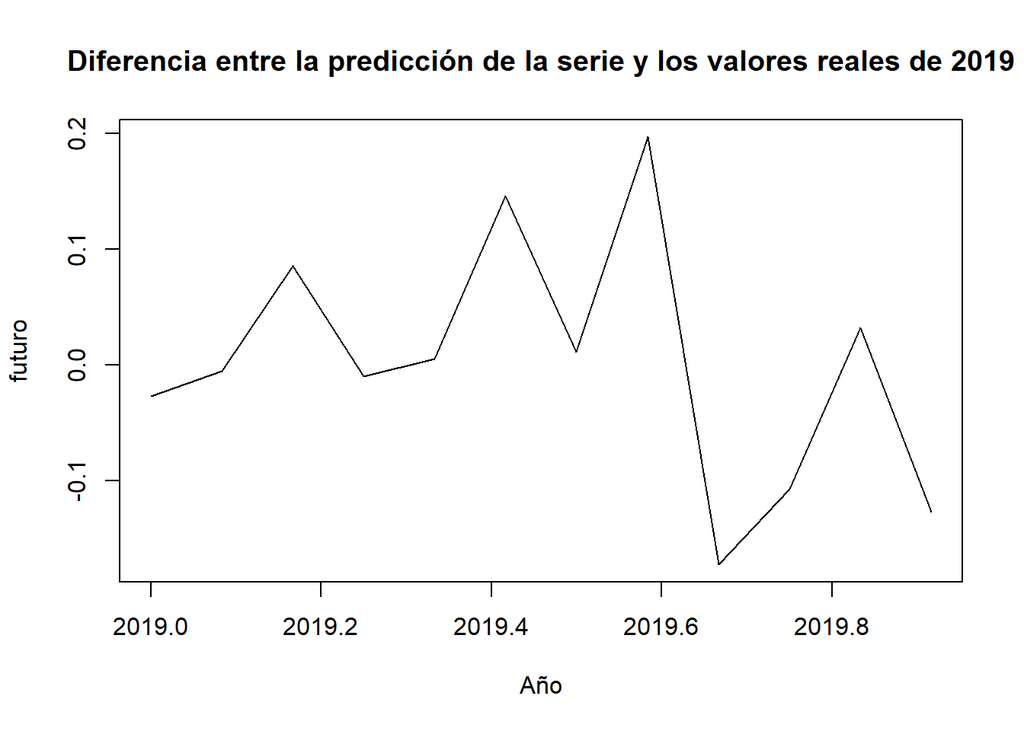

```r
plot(futuro-prediction, main = "Diferencia entre la predicción de la serie y los valores reales de 2019", xlab = "Año")
```

```r
summary(futuro-prediction_bis)
```

```
##      futuro
##  Min.   :-0.28010
##  1st Qu.:-0.11704
##  Median :-0.07003
##  Mean   :-0.07845
##  3rd Qu.:-0.02262
##  Max.   : 0.10762
```

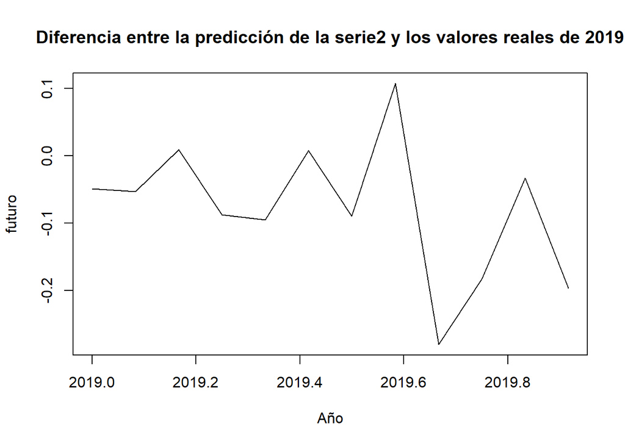

```r
plot(futuro-prediction_bis, main = "Diferencia entre la predicción de la serie2 y los valores reales de 2019", xlab = "Año")
```

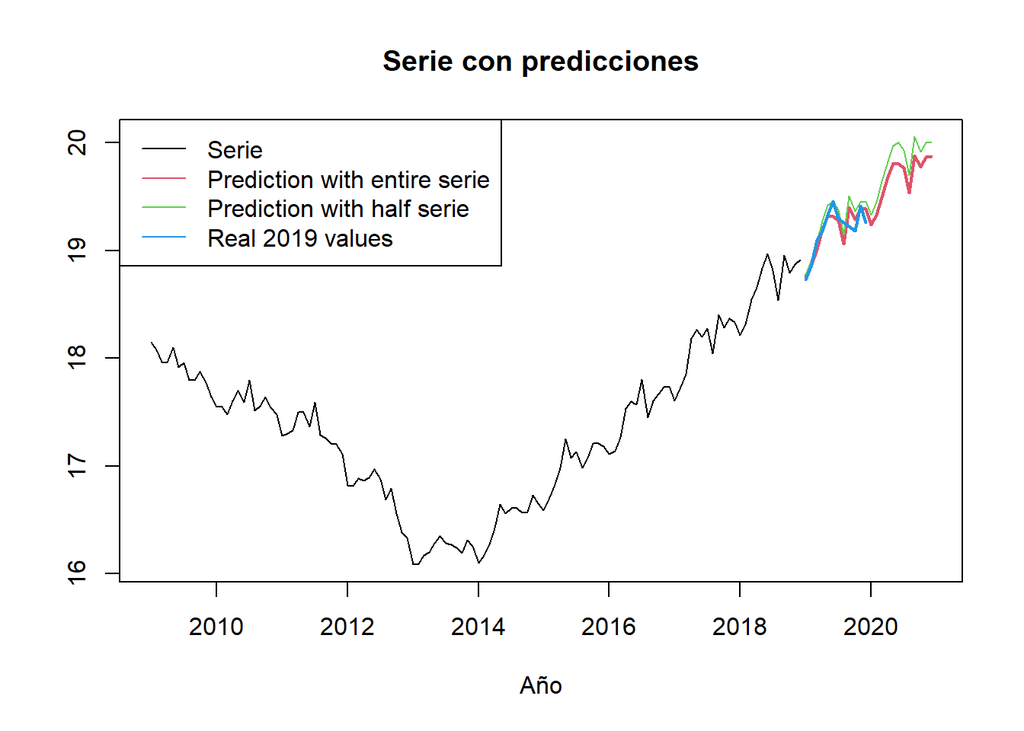

```r
ts.plot(serie, prediction, prediction_bis, futuro, col = c(1,2,3,4), lwd = c(1,2), main = "Serie con predicciones", xlab = "Año")
legend("topleft", legend = c("Serie", "Prediction with entire serie", "Prediction with half serie", "Real 2019 values"), col = c(1,2,3,4), lty = 1, bty = "y")
```

```r
error(futuro,prediction)
```

```
## [1] 0.01058221
```

```r
error(futuro,prediction_bis)
```

```
## [1] 0.01610507
```

### 7.2.2 Segundo año de predicciones (2020, con datos encontrados por la web)

```r
new_data <- c(19.041595,19.279415,18.445436,18.396362,18.584176,18.484270,18.673847,18.591306,18.843729,18.986284,18.974452,18.904852)
extended_futuro <- ts(c(futuro,new_data), start = start(futuro), frequency = frequency(futuro))
extended_futuro
```

```
##           Jan      Feb      Mar      Apr      May      Jun      Jul      Aug
## 2019 18.73063 18.84667 19.09699 19.18264 19.32779 19.45869 19.29034 19.25476
## 2020 19.04160 19.27942 18.44544 18.39636 18.58418 18.48427 18.67385 18.59131
##           Sep      Oct      Nov      Dec
## 2019 19.22364 19.18145 19.41531 19.26164
## 2020 18.84373 18.98628 18.97445 18.90485
```

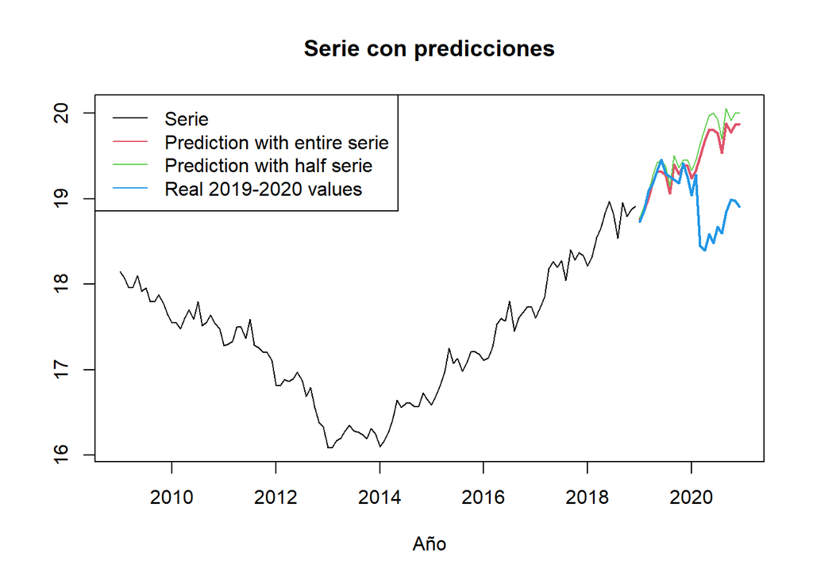

```r
ts.plot(serie, prediction, prediction_bis, extended_futuro, col = c(1,2,3,4), lwd = c(1,2), main = "Serie con predicciones", xlab = "Año")
legend("topleft", legend = c("Serie", "Prediction with entire serie", "Prediction with half serie", "Real 2019-2020 values"), col = c(1,2,3,4), lwd = 1, bty = "y")
```

```r
error(extended_futuro,prediction)
```

```
## [1] 0.4859208
```

```r
error(extended_futuro,prediction_bis)
```

```
## [1] 0.6407204
```

**Observaciones:**  
En 2020 nuestras predicciones fallan completamente. Esto es debido a un fenómeno natural que no pudimos preveer, la pandemia del coronavirus.

**Interpretación:**  
Nuestras predicciones se basan en las observaciones pasadas y patrones repetivivos, no tienen en cuenta factores exógenos. Por ende, presentan limitaciones significativas para predecir eventos extraordinarios como crisis económicas o pandemias.

# Conclusión

El análisis de la serie temporal de afiliados a la Seguridad Social en España (2009-2018) identifica dos etapas clave con dinámicas distintas. La primera, entre 2009 y 2013, refleja el impacto de la crisis económica, con una tendencia decreciente que alcanzó un mínimo histórico de 16.08 millones de afiliados. Este periodo se caracteriza por alta volatilidad y cambios abruptos en el empleo, reflejando la incertidumbre del mercado laboral. La primera subserie es una serie AAM. La segunda etapa, de 2014 a 2018, muestra una recuperación sostenida, con un crecimiento continuo hasta alcanzar un máximo de 18.97 millones de afiliados en 2018. Durante esta fase, se observa mayor estabilidad y normalización del mercado laboral, aunque con fluctuaciones estacionales más pronunciadas. La segunda subserie es una serie AAA.

Aunque los modelos predictivos basados en patrones históricos son efectivos bajo condiciones normales, no logran anticipar eventos extraordinarios como la pandemia de 2020. Esto enfatiza la necesidad de complementar las metodologías tradicionales con enfoques adaptativos o escenarios para manejar incertidumbres externas.